# Taxis de Nueva York

Daniel Serena Sanz

27 Abril de 2020

# Inicialización

El siguiente código ha sido probado con R version 4.0.0 (2020-04-24) y RStudio 1.2.240

Primeramente, es necesario cargar todas las bibliotecas que se van a emplear durante el proyecto.

```r
library(tidyverse)
library(cowplot)
library(hexbin)
library(lubridate)
library(scales)

#theme_set(theme_cowplot(font_size=12)) # reduce default font size
```

Recordar que es preciso instalar previamente aquellas bibliotecas que no estuvieran disponibles. Por ejemplo:

```
install.packages("tidyverse")
```

Cargamos también funciones que nos son útiles en la última parte de la práctica. La función permite `gcd_slc` calcula la distancia geodésica entre dos puntos definidos en coordenadas cartesianas. Precisa de la función `deg2rad` para convertir dichas coordenadas de grados a radianes.

```r
# source: https://www.r-bloggers.com/great-circle-distance-calculations-in-r/
# Convert degrees to radians
deg2rad <- function(deg) {
    return(deg*pi/180)
}

# Calculates the great-circle distance (gdc), also called geodesic distance,
# between two points specified by radian latitude/longitude using the Spherical
# Law of Cosines (slc) The Spherical Law of Cosines performs well as long as the
# distance is not to small (some sources claim it’s accuracy deteriorates at
# about the 1 metre scale).
# Return distance in Km
gcd_slc <- function(long1, lat1, long2, lat2) {
    # Convert degrees to radians
    long1 <- deg2rad(long1)
    lat1 <- deg2rad(lat1)
    long2 <- deg2rad(long2)
    lat2 <- deg2rad(lat2)

    R <- 6371 # Earth mean radius [km]
    d <- acos(sin(lat1)*sin(lat2) + cos(lat1)*cos(lat2) * cos(long2-long1)) * R
    return(d) # Distance in km
}
```

# Carga y limpieza de datos

El conjunto de datos que vamos a utilizar contiene los viajes realizados el día 14 de enero de 2013, y se puede descargar desde:

https://www.dropbox.com/s/nmtodtuvpb8f87d/trip_data_2013-01-14.csv?dl=1

Una vez descargado el fichero, se recomienda incluirlo dentro de un carpeta *data* dentro del directorio donde se haya descargado este *notebook*. La función `read_csv` permite carga el archivo CSV en un *data frame* infiriendo automáticamente el tipo de datos de cada columna.

```r
df <- read_csv("data/trip_data_2013-01-14.csv")
```

El *dataset* tiene los siguientes campos:

```r
colnames(df)
```

```
 [1] "medallion"          "hack_license"       "vendor_id"          "rate_code"          "store_and_fwd_flag" "pickup_datetime"    "dropoff_datetime"   "passenger_count"
 [9] "trip_time_in_secs"  "trip_distance"      "pickup_longitude"   "pickup_latitude"    "dropoff_longitude"  "dropoff_latitude"
```

- **medallion**: la licencia que permite identificar a cada taxi. Más información en https://en.wikipedia.org/wiki/Taxicabs_of_New_York_City#Medallions
- **hack_license**: concesión otorgada a un taxista por la ciudad de NY para poder operar un taxi amarillo (los famosos Yellow Cabs). Se puede utilizar como identificador del conductor. Más información en http://nycitycab.com/HackLicense.aspx
- **vendor_id**: identificador del proveedor tecnológico que suministra el sistema de recolección de datos sobre cada viaje. Por ejemplo, Verifone Transportation Systems (VTS), o Mobile Knowledge Systems Inc (CMT).
- **rate_code**: tarifa a aplicar. Más información en http://www.nyc.gov/html/tlc/html/passenger/taxicab_rate.shtml
- **store_and_fwd_flag**: atributo que se desconoce su utilidad.
- **pickup_datetime**: hora de comienzo del viaje, aaaa-mm-dd hh24:mm:ss EDT.
- **dropoff_datetime**: hora de fin del viaje, aaaa-mm-dd hh24:mm:ss EDT.
- **passenger_count**: número de pasajeros siendo el valor por defecto de uno.
- **trip_time_in_secs**: duración del viaje en segundos.
- **trip_distance**: distancia del viaje en millas.
- **pickup_longitude / pickup_latitude**: coordenadas GPS del origen del viaje.
- **dropoff_longitude / dropoff_latitude**: coordenadas GPS del destino del viaje.

Las marcas de tiempo están referidas al uso horario *Eastern Daylight Time* (EDT) que es donde está ubicado Nueva York, y que corresponde cuatro horas menos respecto a *Coordinated Universal Time* (UTC). Aunque en nuestro caso no afecta, hay que tener en cuanta que los “medallones” y las licencias se reasignan cada año imposibilitando seguir a un mismo conductor o vehículo más allá del año.

# Limpiar registros con datos incorrectos

Antes de comezar cualquier análisis hay que asegurar que el conjunto de datos no contenga valores absurdos. La función `summary` extrae un resumen parámetros donde se pueden ver rápidamente los valores mínimos y máximos, así como la distribución por cuantiles de los mismos.

```r
summary(df)
```

```
  medallion         hack_license        vendor_id           rate_code      store_and_fwd_flag pickup_datetime               dropoff_datetime              passenger_count
 Length:443384      Length:443384      Length:443384      Min.   : 0.000   Length:443384      Min.   :2013-01-13 20:21:53   Min.   :2013-01-14 00:00:00   Min.   :0.000
 Class :character   Class :character   Class :character   1st Qu.: 1.000   Class :character   1st Qu.:2013-01-14 09:40:22   1st Qu.:2013-01-14 09:53:00   1st Qu.:1.000
 Mode  :character   Mode  :character   Mode  :character   Median : 1.000   Mode  :character   Median :2013-01-14 14:52:44   Median :2013-01-14 15:04:09   Median :1.000
                                                          Mean   : 1.036                      Mean   :2013-01-14 14:22:40   Mean   :2013-01-14 14:33:46   Mean   :1.647
                                                          3rd Qu.: 1.000                      3rd Qu.:2013-01-14 19:20:43   3rd Qu.:2013-01-14 19:30:47   3rd Qu.:2.000
                                                          Max.   :28.000                      Max.   :2013-01-14 23:59:18   Max.   :2013-01-14 23:59:59   Max.   :6.000

 trip_time_in_secs trip_distance    pickup_longitude     pickup_latitude    dropoff_longitude    dropoff_latitude
 Min.   :    0.0   Min.   : 0.000   Min.   :-2014.3392   Min.   :-3114.32   Min.   :-1991.0743   Min.   :-3114.27
 1st Qu.:  360.0   1st Qu.: 1.000   1st Qu.:  -73.9914   1st Qu.:   40.74   1st Qu.:  -73.9911   1st Qu.:   40.74
 Median :  540.0   Median : 1.700   Median :  -73.9808   Median :   40.76   Median :  -73.9797   Median :   40.76
 Mean   :  664.5   Mean   : 2.806   Mean   :  -72.6021   Mean   :   40.00   Mean   :  -72.5731   Mean   :   39.98
 3rd Qu.:  840.0   3rd Qu.: 3.000   3rd Qu.:  -73.9662   3rd Qu.:   40.77   3rd Qu.:  -73.9646   3rd Qu.:   40.77
 Max.   :10140.0   Max.   :88.000   Max.   :    0.5717   Max.   : 1609.20   Max.   :    0.0009   Max.   :  646.44
                                                                            NA's   :5            NA's   :5
```

Es nececario entender bien cada variable, incluyendo las unidades si las hubiera y su tipo de datos. Una manera de visualizar la distribución es empleando la función de distribución acumulada empírica (*ECDF*) que muestra la probabilidad (eje y) de que una variable tenga un valor menor o igual que x. Aunque su interpretación es menos intuitiva que un histograma, la visualización es más robusta en cuanto que no depende de un parámetro como puede ser el tamaño del intervalo. En las dos gráficas que se muestran abajo queda claro que tanto la longitud como la latitud tiene un amplio rango de valores que están fuera de lo esperado.

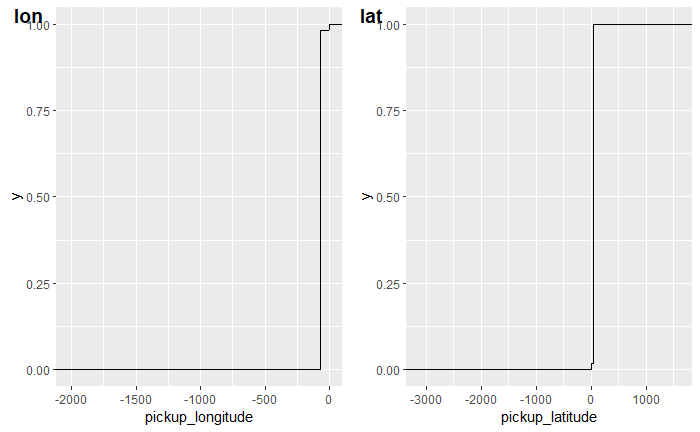

```r
plot1 <- ggplot(df, aes(x=pickup_longitude)) + stat_ecdf()
plot2 <- ggplot(df, aes(x=pickup_latitude)) + stat_ecdf()
plot_grid(plot1, plot2, labels = c('lon', 'lat'))
```

> Q: ¿Qué variables son susceptibles de tener valores incompatibles?

passenger_cout: No tiene sentido que el mínimo sea 0 ya que por defecto el número de pasajeros mínimo es 1. trip_time_in_secs: No tiene sentido que el mínimo sea 0 segudos, ya que bajando la bandera de pasajero el mínimo siempre seria mayor que 0. trip_distance: Salvo caso muy raro, no debería tener mínimo de 0 de distancia. pickup_longitude: El mínimo de longitud del globo terráqueo seria -90, no existe el valor indicado de -2014.3392. Tambien se descartaria por el bounding box de NY. pickup_latitude: En este caso no tiene sentido ni el mínimo ni el máximo. dropoff_longitude: El mínimo no tiene sentido por el mismo motivo que en los dos casos anteriores. dropoff_latitude: El mínimo y el máximo se exceden de las coordenadas máximas de la tierra.

Por ejemplo, ¿tiene sentido que la distancia del viaje o que el tiempo del viaje sea 0?. Una vez identificadas es necesario definir que acciones tomar con estos valores. Una estrategia es imputarle un valor. Por ejemplo, la distancia de viaje se puede aproximar por la distancia desde el origen al destino. El tiempo de viaje se puede hallar la velocidad media, y calcular el tiempo con la distancia. Se puede ser más conservador y cambiar los valores que no son aceptables por `NA` (Not Avaliable).

Esta segunda estrategia es la que se va a seguir en cada una de las variables. Una primera transformación va a ser sustituir aquellas coordenadas de recogida o bajada de pasajeros que no corresponde a la ciudad de Nueva York. Una manera bastante sencilla de delimitar el área de la ciudad es mediante un rectángulo o *bounding box*. Este rectángulo se puede localizar directamente a través de Internet.

> Q: ¿Cual es el *bounding box* de NY?

```r
# Incluir las coordenadas correspondientes, y ejecutar el trozo de código

# -74.25909,40.477399,-73.700181,40.916178
nw <- list(lat = 40.916178, lon = -74.25909)
se <- list(lat = 40.477399, lon = -73.700181)
```

Una vez definido el *bounding box* se sustituye por `NA` cualquier coordenada que se encuentre fuera.

```r
# set coordinates outside of NYC bounding box to NA
df <- df %>%
        mutate(pickup_longitude = replace(pickup_longitude,
                                           which(pickup_longitude < nw$lon
                                                 | pickup_longitude > se$lon),
                                           NA)) %>%
        mutate(pickup_latitude = replace(pickup_latitude,
                                           which(pickup_latitude < se$lat
                                                 | pickup_latitude > nw$lat),
                                           NA)) %>%
        mutate(dropoff_longitude = replace(dropoff_longitude,
                                           which(dropoff_longitude < nw$lon
                                                 | dropoff_longitude > se$lon),
                                           NA)) %>%
        mutate(dropoff_latitude = replace(dropoff_latitude,
                                           which(dropoff_latitude < se$lat
                                                 | dropoff_latitude > nw$lat),
                                           NA))
```

> T: Realizar transformaciones similares en el resto de atributos que lo necesiten

```r
df <- df %>%
        mutate(trip_distance = replace(trip_distance,
                                           which(trip_distance == 0),
                                       NA)) %>%
        mutate(passenger_count = replace(passenger_count,
                                           which(passenger_count == 0),
                                         NA)) %>%
        mutate(trip_time_in_secs = replace(trip_time_in_secs,
                                           which(trip_time_in_secs <= 0),
                                           NA))
```

```r
summary(df)
```

```
  medallion         hack_license        vendor_id           rate_code      store_and_fwd_flag pickup_datetime               dropoff_datetime              passenger_count
 Length:443384      Length:443384      Length:443384      Min.   : 0.000   Length:443384      Min.   :2013-01-13 20:21:53   Min.   :2013-01-14 00:00:00   Min.   :1.000
 Class :character   Class :character   Class :character   1st Qu.: 1.000   Class :character   1st Qu.:2013-01-14 09:40:22   1st Qu.:2013-01-14 09:53:00   1st Qu.:1.000
 Mode  :character   Mode  :character   Mode  :character   Median : 1.000   Mode  :character   Median :2013-01-14 14:52:44   Median :2013-01-14 15:04:09   Median :1.000
                                                          Mean   : 1.036                      Mean   :2013-01-14 14:22:40   Mean   :2013-01-14 14:33:46   Mean   :1.647
                                                          3rd Qu.: 1.000                      3rd Qu.:2013-01-14 19:20:43   3rd Qu.:2013-01-14 19:30:47   3rd Qu.:2.000
                                                          Max.   :28.000                      Max.   :2013-01-14 23:59:18   Max.   :2013-01-14 23:59:59   Max.   :6.000
                                                                                                                                                          NA's   :5
 trip_time_in_secs trip_distance    pickup_longitude pickup_latitude dropoff_longitude dropoff_latitude
 Min.   :    1     Min.   : 0.010   Min.   :-74.26   Min.   :40.48   Min.   :-74.26    Min.   :40.48
 1st Qu.:  360     1st Qu.: 1.000   1st Qu.:-73.99   1st Qu.:40.74   1st Qu.:-73.99    1st Qu.:40.74
 Median :  540     Median : 1.700   Median :-73.98   Median :40.76   Median :-73.98    Median :40.76
 Mean   :  666     Mean   : 2.823   Mean   :-73.97   Mean   :40.75   Mean   :-73.97    Mean   :40.75
 3rd Qu.:  840     3rd Qu.: 3.000   3rd Qu.:-73.97   3rd Qu.:40.77   3rd Qu.:-73.97    3rd Qu.:40.77
 Max.   :10140     Max.   :88.000   Max.   :-73.70   Max.   :40.92   Max.   :-73.70    Max.   :40.92
 NA's   :1020      NA's   :2622     NA's   :8318     NA's   :8198    NA's   :8638      NA's   :8479
```

```
Removed 8318 rows containing non-finite values (stat_ecdf).Removed 8198 rows containing non-finite values (stat_ecdf).
```

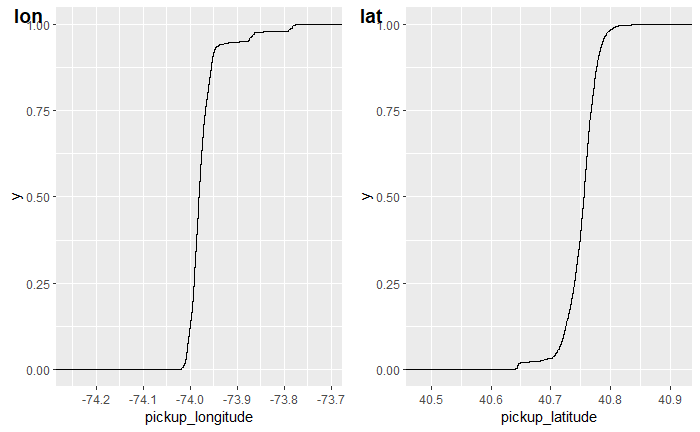

```r
plot1 <- ggplot(df, aes(x=pickup_longitude)) + stat_ecdf()
plot2 <- ggplot(df, aes(x=pickup_latitude)) + stat_ecdf()
plot_grid(plot1, plot2, labels = c('lon', 'lat'))
```

Una vez terminadas la limpieza es conveniente identificar el impacto que ha tenido en cada variable:

```r
sapply(df, function(y) sum(is.na(y)))
```

```
         medallion       hack_license          vendor_id          rate_code store_and_fwd_flag    pickup_datetime   dropoff_datetime    passenger_count  trip_time_in_secs
                 0                  0                  0                  0             216328                  0                  0                  5               1020
     trip_distance   pickup_longitude    pickup_latitude  dropoff_longitude   dropoff_latitude
              2622               8318               8198               8638               8479
```

y en total cuantos registros han sido afectados. Antes eliminamos el atributo *store_and_fwd_flag* ya que tiene un número elevado de `NA`, y además no sabemos interpretar.

```r
df <- df %>% select(-store_and_fwd_flag)
table(complete.cases(df))
```

```
 FALSE   TRUE
 11205 432179
```

> Q: ¿Cuál es porcentaje de registros que contienen algún campo invalidos (NA) sin contar store_and_fwd_flag? ¿Existe alguna variable que tenga un número de valores inválidos superior al 10%?

```r
col <- colnames(df, do.NULL = FALSE, prefix="row")
for (i in 0:ncol(df)){
  print(col[i])
  ok <- complete.cases(df[i])
  print(table(ok))
  percentageNAN = (sum(!ok)/(sum(ok)+sum(!ok)))
  print(percentageNAN)

}
```

```
character(0)
ok
  TRUE
443384
[1] 0
[1] "medallion"
ok
  TRUE
443384
[1] 0
[1] "hack_license"
ok
  TRUE
443384
[1] 0
[1] "vendor_id"
ok
  TRUE
443384
[1] 0
[1] "rate_code"
ok
  TRUE
443384
[1] 0
[1] "pickup_datetime"
ok
  TRUE
443384
[1] 0
[1] "dropoff_datetime"
ok
  TRUE
443384
[1] 0
[1] "passenger_count"
ok
 FALSE   TRUE
     5 443379
[1] 1.127691e-05
```

[output cut: 15 more lines]

```
[1] "pickup_latitude"
ok
 FALSE   TRUE
  8198 435186
[1] 0.01848962
[1] "dropoff_longitude"
ok
 FALSE   TRUE
  8638 434746
[1] 0.01948198
[1] "dropoff_latitude"
ok
 FALSE   TRUE
  8479 434905
[1] 0.01912338
```

Una vez dispuesto un conjunto de datos limpios vamos a comenzar con una serie de preguntas básicas que permiten entender un poco más en detalle cómo conducen los taxista en Nueva York.

> Q: ¿Cuantos viajes se hacen en promedio por un mismo taxista? ¿y cómo máximo?

Esta pregunta se puede responder mediante la función `summary` o gráficamente pintando tanto la *ecdf* como el histograma. En todos los casos, es preciso primero contabilizar el número de viajes que hace cada taxista para lo cual se emplea la función `table`

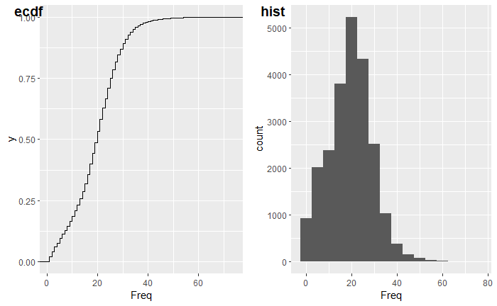

```r
hack_license <- as.data.frame(table(df$hack_license))
plot1 <- ggplot(hack_license, aes(Freq)) + stat_ecdf()
plot2 <- ggplot(hack_license, aes(Freq)) + geom_histogram(binwidth = 5)
plot_grid(plot1, plot2, labels = c("ecdf", "hist"))
```

```r
#table(df[1])
summary(df)
```

```
  medallion         hack_license        vendor_id           rate_code      pickup_datetime               dropoff_datetime              passenger_count trip_time_in_secs
 Length:443384      Length:443384      Length:443384      Min.   : 0.000   Min.   :2013-01-13 20:21:53   Min.   :2013-01-14 00:00:00   Min.   :1.000   Min.   :    1
 Class :character   Class :character   Class :character   1st Qu.: 1.000   1st Qu.:2013-01-14 09:40:22   1st Qu.:2013-01-14 09:53:00   1st Qu.:1.000   1st Qu.:  360
 Mode  :character   Mode  :character   Mode  :character   Median : 1.000   Median :2013-01-14 14:52:44   Median :2013-01-14 15:04:09   Median :1.000   Median :  540
                                                          Mean   : 1.036   Mean   :2013-01-14 14:22:40   Mean   :2013-01-14 14:33:46   Mean   :1.647   Mean   :  666
                                                          3rd Qu.: 1.000   3rd Qu.:2013-01-14 19:20:43   3rd Qu.:2013-01-14 19:30:47   3rd Qu.:2.000   3rd Qu.:  840
                                                          Max.   :28.000   Max.   :2013-01-14 23:59:18   Max.   :2013-01-14 23:59:59   Max.   :6.000   Max.   :10140
                                                                                                                                       NA's   :5       NA's   :1020
 trip_distance    pickup_longitude pickup_latitude dropoff_longitude dropoff_latitude
 Min.   : 0.010   Min.   :-74.26   Min.   :40.48   Min.   :-74.26    Min.   :40.48
 1st Qu.: 1.000   1st Qu.:-73.99   1st Qu.:40.74   1st Qu.:-73.99    1st Qu.:40.74
 Median : 1.700   Median :-73.98   Median :40.76   Median :-73.98    Median :40.76
 Mean   : 2.823   Mean   :-73.97   Mean   :40.75   Mean   :-73.97    Mean   :40.75
 3rd Qu.: 3.000   3rd Qu.:-73.97   3rd Qu.:40.77   3rd Qu.:-73.97    3rd Qu.:40.77
 Max.   :88.000   Max.   :-73.70   Max.   :40.92   Max.   :-73.70    Max.   :40.92
 NA's   :2622     NA's   :8318     NA's   :8198    NA's   :8638      NA's   :8479
```

> Q: ¿Cuantos viajes se hacen en promedio por un mismo taxi? ¿Qué relación existe con los viajes por los taxistas?

> Q: ¿Cuál es el tiempo medio y la distancia media de un carrera?

Tiempo medio de una carrera es de 11 minutos y 6 segundos, con un mmínimo de 1 segundo y un máximo de 2 horas y 49 minutos. Distancia media de una carrera es de 2.823 millas.

> Q: ¿Cuál es la velocidad media a la que conducen los taxis en Nueva York?

Cogiendo la distancia media y el tiempo medio obtemos que conducen de velocidad media a 24,54 km/h.

2.823/(666/3600)=millas/hora -> * 1.60934 -> km/h

> Q: ¿Cómo es la distribución del número de pasajeros por viaje?

# Distribución de los viajes

Una de las información clave siempre que analizamos datos geoposicionados es la distribución de los mismos. En este caso, tenemos tanto los puntos de origen como de destino de cada viajes, pudiendo analizar las zonas de la ciudad donde se recogen a los pasajeros y se dejan a los viajeros.

```
Removed 8357 rows containing non-finite values (stat_binhex).Removed 8739 rows containing non-finite values (stat_binhex).
```

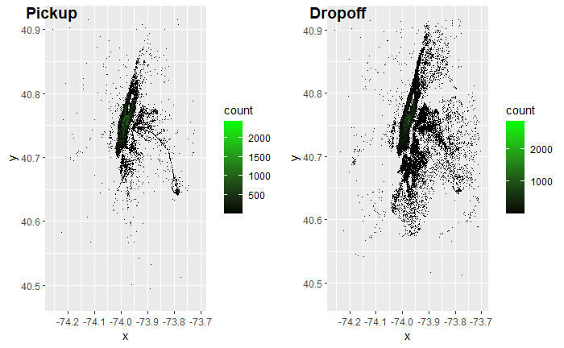

```r
pickup_lonlat <- data.frame(x=df$pickup_longitude, y=df$pickup_latitude)
plot_pickup <- ggplot(pickup_lonlat) + stat_binhex(aes(x=x, y=y), bins=300) +
                                        scale_fill_gradientn(colours=c("black","green"))

dropoff_lonlat <- data.frame(x=df$dropoff_longitude, y=df$dropoff_latitude)
plot_dropoff <- ggplot(dropoff_lonlat) + stat_binhex(aes(x=x, y=y), bins=300) +
                                         scale_fill_gradientn(colours=c("black","green"))

plot_grid(plot_pickup, plot_dropoff, labels = c('Pickup', 'Dropoff'))
```

> Q: ¿Cómo intepretas las diferencias y simulitudes en las distribución de recogidas y bajadas de viajeros?

La mayoría de recogidas se realizan en las mismas zonas, Manhattan, mientras que las bajadas se ven distribuidas por todo nueva york, estoy puede ser debido a que los ciudadanos usan el taxi para volver a sus domicilios despues de trabajar, habría que hacer otra gráfica con las horas de bajada y subida de pasajeros para contrastar esta hipótesis. No obstante aqui se puede apreciar datos de cuando se suele coger el taxi y cuando se suele dejar, ambos despues del medio dia, que puede coincidir con el final de media jornada de trabajo.

pickup_datetime dropoff_datetime  
Mean :2013-01-14 14:22:40 Mean :2013-01-14 14:33:46

# Número de viajes a lo largo del día

De la misma manera, podemos estudiar cómo varía el número de viajes en función de la hora día, obteniendo una aproximación al ciclo vida diario de la ciudad.

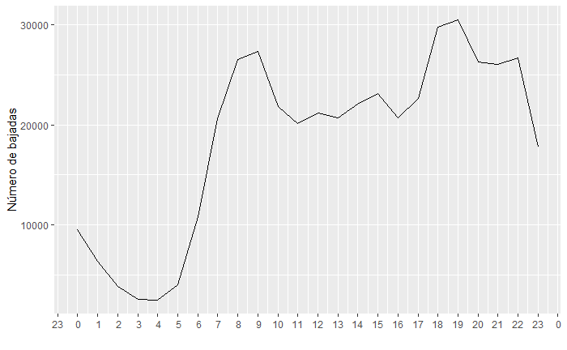

```r
dropoffs <- data.frame(time=sort(df$dropoff_datetime))
dropoff_by_hour <- cut(dropoffs$time, breaks="1 hour", labels=FALSE)-1

ts_dropoff <- dropoffs %>%
                mutate(hour = dropoff_by_hour) %>%
                group_by(hour) %>%
                summarise(freq = length(hour))

ts_dropoff$hour <- as.POSIXct(ts_dropoff$hour*3600, origin = "1970-01-01", tz = "UTC")

ggplot(ts_dropoff, aes(hour, freq)) + geom_line() +
        scale_x_datetime(labels = date_format("%k"),
                     breaks = date_breaks("1 hour"),
                     minor_breaks = date_breaks("30 min")) +
                     xlab("") + ylab("Número de bajadas")
```

> Q: Describir este ciclo de actividad de la ciudad, y estudiar la relación que existe con el número de recogidas por hora

# ¿Cuanto se tarda en llegar al aeropuerto JFK en taxi?

Sin duda, una de las preguntas que muchos turista que visitan Nueva York se hacen con más frecuencia. Y más importante, cómo varía este tiempo según la hora del día.

Lo primero que necesitamos es determinar dónde se encuentra el aeropuerto JFK

> Q: ¿Cual es el *bounding box* de JFK?

```r
#-73.8352, 40.6195, -73.7401, 40.6659.
jfk_nw <- list(lat = 40.660052, lon = -73.821412)
jfk_se <- list(lat = 40.631317, lon = -73.758051)
```

Así podemos obtener todos las recogidas que se producen en un día en JFK

```r
jfk_pickups <- df %>%
                    filter(jfk_nw$lon < pickup_longitude & pickup_longitude < jfk_se$lon ) %>%
                    filter(jfk_se$lat < pickup_latitude & pickup_latitude < jfk_nw$lat)
```

y todos los taxis que dejan viajeros en el aeropuerto

```r
jfk_dropoffs <- df %>%
                    filter(jfk_nw$lon < dropoff_longitude & dropoff_longitude < jfk_se$lon ) %>%
                    filter(jfk_se$lat < dropoff_latitude & dropoff_latitude < jfk_nw$lat)
```

```r
print("JFK_PICKUPS")
```

```
[1] "JFK_PICKUPS"
```

```r
print(nrow(jfk_pickups))
```

```
[1] 8796
```

```r
print("JFK_DROPOFFS")
```

```
[1] "JFK_DROPOFFS"
```

```r
print(nrow(jfk_dropoffs))
```

```
[1] 2835
```

Simplemente contando el número de registros en cada uno de los *data_frame* anteriores ya podemos responder a:

> Q: ¿La gente coje el taxi para ir al aeropuerto o para venir del aeropuerto?

Para venir del aeropuerto.

> Q: ¿Qué porcentaje de los viajes en un día comienza o terminan en el aeropuerto?

Si el número de rows en la base de datos es de 443384 y el numero de salidas y llegadas del aeropuerto es de 11631, el porcentaje es de 2.62 %

También nos puede interesar a dónde van los taxis desde el aeropuerto, y

```r
jfk_pickup_lonlat <- data.frame(x=jfk_pickups$dropoff_longitude, y=jfk_pickups$dropoff_latitude)
jfk_plot_pickup <- ggplot(jfk_pickup_lonlat) + stat_binhex(aes(x=x, y=y), bins=300) +
                                        scale_fill_gradientn(colours=c("black","green"))
```

desde dónde se cogen taxis hacia el aeropuerto

```r
jfk_dropoff_lonlat <- data.frame(x=jfk_dropoffs$pickup_longitude, y=jfk_dropoffs$pickup_latitude)
jfk_plot_dropoff <- ggplot(jfk_dropoff_lonlat) + stat_binhex(aes(x=x, y=y), bins=300) +
                                         scale_fill_gradientn(colours=c("black","green"))
```

```
Removed 140 rows containing non-finite values (stat_binhex).Removed 5 rows containing non-finite values (stat_binhex).
```

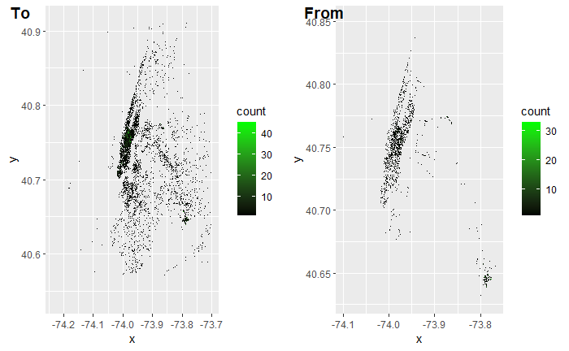

```r
plot_grid(jfk_plot_pickup, jfk_plot_dropoff, labels = c('To', 'From'))
```

> Q: ¿Qué diferencias existen entre los viajes que van hace el aeropuerto y los que parten de él?

y, por fin, ¿cuanto se tarda en llegar al aeropuerto? Como la mayoría de los taxi se toman desde Manhattan vamos a tomar esa zona como referencia.

Calculamos el *bounding_box* aproximado:

```r
manh_nw <- list(lat = 40.881333, lon = -74.017639)
manh_se <- list(lat = 40.700943, lon = -73.910522)
```

obtenemos todos los viajes desde Manhantan al JFK

```r
trips_manh_jfk <- df %>%
                    filter(manh_nw$lon < pickup_longitude & pickup_longitude < manh_se$lon ) %>%
                    filter(manh_se$lat < pickup_latitude & pickup_latitude < manh_nw$lat) %>%
                    filter(jfk_nw$lon < dropoff_longitude & dropoff_longitude < jfk_se$lon ) %>%
                    filter(jfk_se$lat < dropoff_latitude & dropoff_latitude < jfk_nw$lat)
```

y ya podemos pintar la distribución de cuanto se tarda:

```
Removed 1 rows containing non-finite values (stat_ecdf).Removed 1 rows containing non-finite values (stat_bin).
```

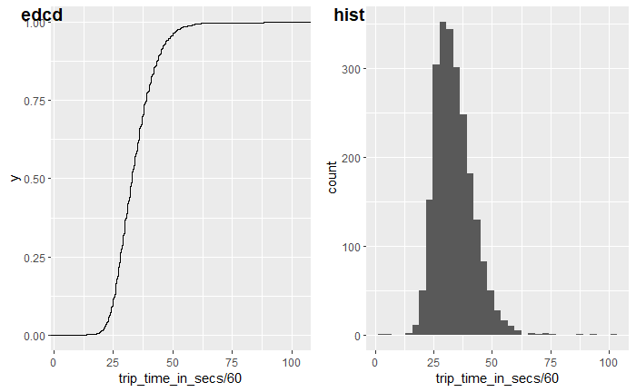

```r
plot1 <- ggplot(trips_manh_jfk, aes(trip_time_in_secs/60)) + stat_ecdf()
plot2 <- ggplot(trips_manh_jfk, aes(trip_time_in_secs/60)) + geom_histogram(bins = 35)
plot_grid(plot1, plot2, labels= c("edcd", "hist"))
```

> Q: ¿La mayor parte de los taxis (95%) que intervalo de tiempos tardan en llegar al JFK?

Puedes emplear la función `quantile` si quieres calcular exactamente.

De nuevo, nos interesa ver la distribución de la duración del viaje dependiendo de las horas del día, dado que el tráfico varía sensiblemente. Como dentro de una franja horaria también puede haber una variabilidad elevada, vamos a dibujar los intervalos de confianza además del promedio

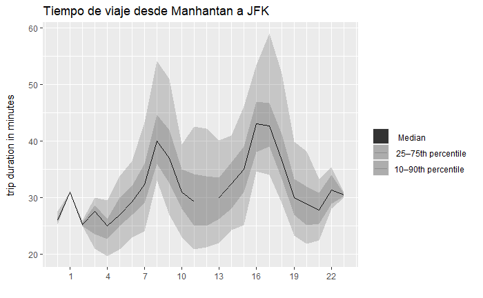

```r
dropoff_by_hour <- cut(trips_manh_jfk$dropoff_datetime, breaks="1 hour", labels=FALSE)-1

ts_dropoff <- trips_manh_jfk %>%
                            mutate(hour = dropoff_by_hour) %>%
                            group_by(hour) %>%
                            summarise(q5 = quantile(trip_time_in_secs/60, prob=0.05, na.rm = TRUE),
                                      q25 = quantile(trip_time_in_secs/60, prob=0.25, na.rm = TRUE),
                                      q50 = median(trip_time_in_secs/60),
                                      q75 = quantile(trip_time_in_secs/60, prob=0.75, na.rm = TRUE),
                                      q95 = quantile(trip_time_in_secs/60, prob=0.95, na.rm = TRUE))

ts_dropoff$hour <- as.POSIXct(ts_dropoff$hour*3600, origin = "1970-01-01", tz = "UTC")
ggplot(ts_dropoff, aes(x=hour)) +
        geom_line(aes(y=q50, alpha = "  Median   ")) +
        geom_ribbon(aes(ymin = q25, ymax = q75, alpha = " 25–75th percentile   ")) +
        geom_ribbon(aes(ymin = q5, ymax = q95, alpha = "10–90th percentile")) +
        scale_alpha_manual("", values = c(1, 0.2, 0.2)) +
        scale_y_continuous("trip duration in minutes\n") +
        scale_x_datetime(labels = date_format("%k"),
                     breaks = date_breaks("3 hours"),
                     minor_breaks = date_breaks("1 hour")) +
        xlab("") + ylab("Min") +
        ggtitle("Tiempo de viaje desde Manhantan a JFK")
```

> Q: ¿Cómo explica el ciclo de activida diaria que hemos dibujado antes esta gráfica?

En los dos picos que se muestran es donde habría más tráfico, a las 8 y sobre las 16.30

> Q: ¿Qué franja horario es la que tiene más variabilidad de duración de viaje?

# Nueva York de día y noche

Otro aspecto importante para los turistas es donde se puede descansar y donde se puede salir a tomar algo, y algunos, incluso querrán que tener ambas zonas lo más cercano posible. Para responder a este pregunta tenemos que dividir el conjunto de datos según la hora de día.

> Q: ¿Cuando comienza y termina la actividad diurna?

Para determinar esta estimación puedes emplear gráficas anteriores o ir a buscar a Internet

```r
# Incluir tu estimación propia de cada umbral (0-23)
start_daytime <- 8
end_daytime <- 17
```

Partimos el *dataset* en viajes nocturnos y diurnos

```r
daytime <- df %>% filter(start_daytime <= hour(pickup_datetime) & hour(pickup_datetime) < end_daytime)
nighttime <- df %>% filter(! (start_daytime <= hour(pickup_datetime) & hour(pickup_datetime) < end_daytime))
```

y pintamos la distribución de los puntos partida de los taxis según el momento del día

```
Removed 3991 rows containing non-finite values (stat_binhex).Removed 4366 rows containing non-finite values (stat_binhex).
```

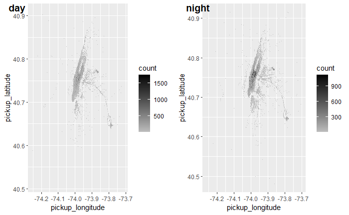

```r
daytime_plot <- ggplot(daytime) + stat_binhex(aes(x=pickup_longitude, y=pickup_latitude), bins=300) +
                                         scale_fill_gradientn(colours=c("gray","black"))
nighttime_plot <- ggplot(nighttime) + stat_binhex(aes(x=pickup_longitude, y=pickup_latitude), bins=300) +
                                         scale_fill_gradientn(colours=c("gray","black"))

plot_grid(daytime_plot, nighttime_plot, labels = c("day", "night"))
```

> Q: ¿Qué diferencias y similitudes existe entre el horario diurno y nocturno?

La gráfica de día esta contenido en la gráfica de noche, mientras que en la de noche se ve un incremento de toma de taxis en la zona de Manhattan.

# Parte de desarrollo propio

La última parte de la práctica consiste en realizar un desarrollo propio en el que se van a combinar un nuevo conjunto de datos con los ya existente.

Desde esta URL:

https://www.dropbox.com/s/lowbxfx2uohlxy3/All_Starbucks_Locations_in_the_US_2013.csv?dl=1

te puedes bajar todas las ubicaciones que tenían los Starbucks de Estados Unidos en el año 2013. Se pide estimar los *cinco Starbucks* que tienen más clientes a partir de la actividad de los taxis.